# Brewer’s Association of America

Predicting Craft Beer Preferences

James Vasquez, Daniel Serna, Kumar Ramasundaram, Lance Dacy

June 28, 2018

# Introduction

According to a recent [article in Forbes](https://www.forbes.com/sites/garystoller/2018/03/20/craft-breweries-dominate-the-top-50-but-guess-which-giants-rule-the-beer-market/#3b6528dedcad), MillerCoors *(which owns Blue Moon, Pilsener Urquell and numerous brands besides Miller and Coors products)*, ranks No. 2 in volume of beer produced for sale. Constellation Brands is No. 3 with its various brands, including Corona and Modelo.

The traditional giants have bought some craft breweries in recent years, blurring the lines between craft and non-craft brewing companies. Anheuser-Busch bought 10 Barrel Brewing of Bend, Oregon, and Constellation Brands purchased Sand Diego-based Ballast Point for $1 billion.

This signifies that Craft beers have grown in popularity since the early 2000’s and have skyrocketed in 2010 (see Figure 1 below).

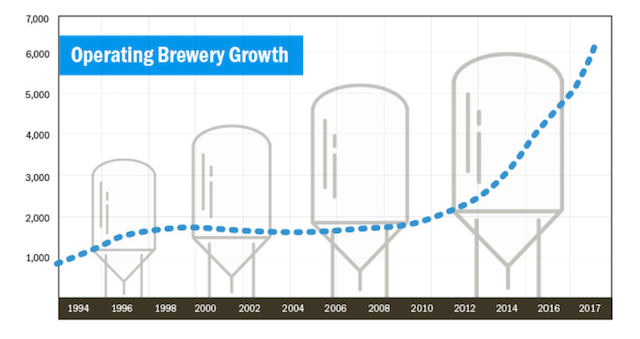

In the US alone there are well over 150 styles of beer with as many breweries in each state. Knowing the [palate](https://www.pastemagazine.com/blogs/lists/2014/09/7-ways-to-be-a-better-beer-taster.html) of potential customers can gain your brewery an edge in profit margins by staying close their preferences. Even more important is that the various regions in the USA might actually have variying taste / alcohol content preferences from other regions.

[Brewer’s Association of America](https://www.brewersassociation.org), has supplied data and various questions to **JVKRDSLD and Associates** to conduct a study for would-be investors to better understand the chances of product success in today’s hyper-competative market.

```r
#Load necessary libraries for the project.
#Install the ggplot2 package if it is not already installed.
if(!require(ggplot2)) install.packages("ggplot2", repos = "https://cran.rstudio.com/bin/windows/contrib/3.5/ggplot2_2.2.1.zip")
#Install the DataExplorer package if it is not already installed.
if(!require(DataExplorer)) install.packages("DataExplorer", repos = "https://cran.rstudio.com/bin/windows/contrib/3.5/DataExplorer_0.6.0.zip")
#Install the dplyr package if it is not already installed.
if(!require(dplyr)) install.packages("dplyer", repos = "https://cran.rstudio.com/bin/windows/contrib/3.5/dplyr_0.7.5.zip")
#Install the usmap package if it is not already installed.
if(!require(usmap)) install.packages("usmap", repos = "https://cran.rstudio.com/bin/windows/contrib/3.5/usmap_0.3.0.zip")
# library(ggplot2)
# library(DataExplorer)
# library(dplyr)
# library(usmap)
```

## Brewery Count and Location

The first question to answer for the BAA is how many breweries are there in the USA and what is their location. The results indicate which states may be over populated with breweries and states that have not seen a wild growth in breweries. This is beneficial in determining which market to target based on saturation.

```r
#Read both raw CSV files into R for data tidying and maniupulation
Beers <- read.csv("Beers.csv", header=TRUE, sep=",", strip.white = TRUE)
Breweries <- read.csv("Breweries.csv", header=TRUE, sep=",", strip.white = TRUE)

#Create State DB data frame
StateDB <- data.frame(state.name, state.abb, state.region)

#Rename columns for readability
colnames(StateDB)[colnames(StateDB)=='state.name'] <- 'StateName'
colnames(StateDB)[colnames(StateDB)=='state.abb'] <- 'State'
colnames(StateDB)[colnames(StateDB)=='state.region'] <- 'StateRegion'

#Add district of Columbia to StateDB Data Frame
DistrictColumbia <- data.frame("District of Columbia","DC", "South")
names(DistrictColumbia) <- c("StateName","State", "StateRegion")
StateDB <- rbind(StateDB, DistrictColumbia)

#Create object to hold the counts of breweries by state
BreweryCounts <- data.frame(table(Breweries$State))

#rename column names
colnames(BreweryCounts)[colnames(BreweryCounts)=='Var1'] <- 'State'
colnames(BreweryCounts)[colnames(BreweryCounts)=='Freq'] <- 'NumberOfBreweriesByState'

#Merge the StateDB and sort by count of breweries by state
BreweryCounts <- merge(BreweryCounts, StateDB, by.x=("State"), by.y=("State"))
BreweryCounts <- BreweryCounts[order(BreweryCounts$NumberOfBreweriesByState, decreasing=TRUE),c(3,2)]
BreweryCounts
```

```
##               StateName NumberOfBreweriesByState
## 6              Colorado                       47
## 5            California                       39
## 23             Michigan                       32
## 38               Oregon                       29
## 44                Texas                       28
## 39         Pennsylvania                       25
## 20        Massachusetts                       23
## 48           Washington                       23
## 16              Indiana                       22
## 49            Wisconsin                       20
## 28       North Carolina                       19
## 15             Illinois                       18
## 35             New York                       16
## 46             Virginia                       16
```

[output cut: 37 more lines]

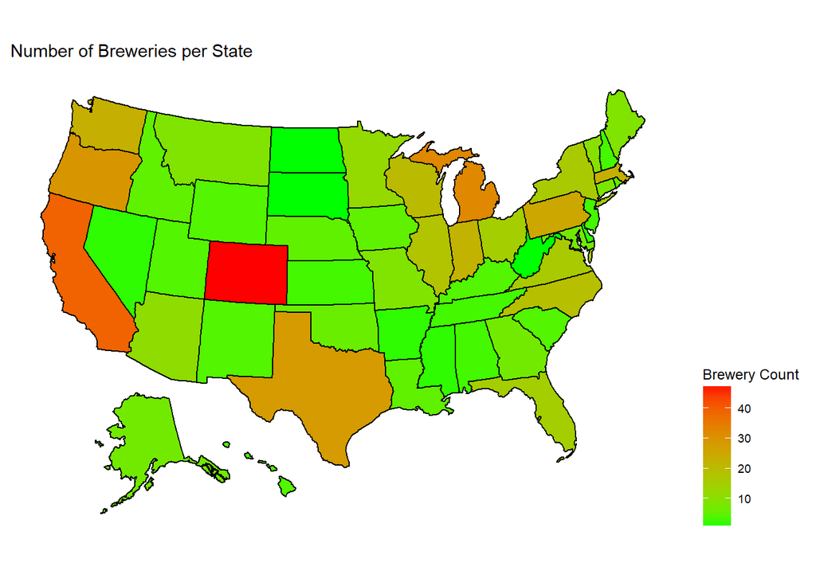

```r
#Merge BreweryCounts to the statepop data set by state name
BreweryCountsMap <- merge(statepop, BreweryCounts, by.x=("full"), by.y=("StateName"))

#Plot states and color by brewery counts
usmap::plot_usmap(data = BreweryCountsMap,
                        values = "NumberOfBreweriesByState",
                        lines = "black") + scale_fill_continuous(
                        low = "green",
                        high = "red",
                        name = "Brewery Count",
                        label = scales::comma) + theme(legend.position = "right")+
                        labs(title = "Number of Breweries per State")
```

## Making Sense of the Data

In an effort to understand the relationship between the types of beers sold as well as the breweries that made them, the beer and breweries data sets were merged along side the states database. To check-in on the merged data-set, we will review the first and last 6 rows of the data to get a sense of the type of information we are working with in order to evaluate to our final lists of questions provided by the BAA.

```r
#join data on Brewery_id and Brew_ID
BeersAndBreweries <- merge(Beers, Breweries, by.x=("Brewery_id"), by.y=("Brew_ID"))

#rename the name.x(Beer) and name.y(Brewery) after the merge for consistency
colnames(BeersAndBreweries)[colnames(BeersAndBreweries)=='Name.x'] <- 'BeerName'
colnames(BeersAndBreweries)[colnames(BeersAndBreweries)=='Name.y'] <- 'BreweryName'

#Merge data with State DB
BeersAndBreweries <- merge(BeersAndBreweries, StateDB, by="State", all = TRUE)

#Show first and last 6 entries of merged files
head(BeersAndBreweries)
```

```
##   State Brewery_id                   BeerName Beer_ID   ABV IBU
## 1    AK        103            King Street IPA    1667 0.060  70
## 2    AK        103                  Amber Ale    2436 0.051  NA
## 3    AK        494             Polar Pale Ale     920 0.052  17
## 4    AK        459          Sunken Island IPA     349 0.068  NA
## 5    AK        103        King Street Pilsner    1706 0.055  NA
## 6    AK        459 Skilak Scottish Ale (2011)     348 0.058  NA
##                      Style Ounces                  BreweryName      City
## 1             American IPA     12  King Street Brewing Company Anchorage
## 2 American Amber / Red Ale     12  King Street Brewing Company Anchorage
## 3  American Pale Ale (APA)     12 Broken Tooth Brewing Company Anchorage
## 4             American IPA     12  Kenai River Brewing Company  Soldotna
## 5           Czech Pilsener     12  King Street Brewing Company Anchorage
## 6             Scottish Ale     12  Kenai River Brewing Company  Soldotna
##   StateName StateRegion
## 1    Alaska        West
## 2    Alaska        West
## 3    Alaska        West
## 4    Alaska        West
## 5    Alaska        West
## 6    Alaska        West
```

```r
tail(BeersAndBreweries)
```

```
##      State Brewery_id                         BeerName Beer_ID   ABV IBU
## 2405    WY        458    Saddle Bronc Brown Ale (2013)    1198 0.048  16
## 2406    WY        192                   Pakoâ\200\231s EyePA     393 0.068  60
## 2407    WY        192               Snow King Pale Ale    1606 0.060  55
## 2408    WY        458             Wagon Box Wheat Beer    1197 0.059  15
## 2409    WY        458            Indian Paintbrush IPA    1199 0.070  75
## 2410    WY        458 Bomber Mountain Amber Ale (2013)    1200 0.046  20
##                         Style Ounces                     BreweryName
## 2405        English Brown Ale     12 The Black Tooth Brewing Company
## 2406             American IPA     12     Snake River Brewing Company
## 2407  American Pale Ale (APA)     12     Snake River Brewing Company
## 2408  American Pale Wheat Ale     12 The Black Tooth Brewing Company
## 2409             American IPA     12 The Black Tooth Brewing Company
## 2410 American Amber / Red Ale     12 The Black Tooth Brewing Company
##          City StateName StateRegion
## 2405 Sheridan   Wyoming        West
## 2406  Jackson   Wyoming        West
## 2407  Jackson   Wyoming        West
## 2408 Sheridan   Wyoming        West
## 2409 Sheridan   Wyoming        West
## 2410 Sheridan   Wyoming        West
```

## Determine Any Missing Values

As with any raw data-sets, checks had to be instituted for missing values. Providing statistical analysis will serve our client best if we understand the missing values to ensure the results are minimally skewed. A report for both a graphical and tabular representation of the results is provided below. The team utilized an example library from [Genetics & Bioinformatics Research](http://www.gettinggeneticsdone.com/2011/02/summarize-missing-data-for-all.html) to count missing values. The data shows the variables with missing data are the IBU and ABV values.

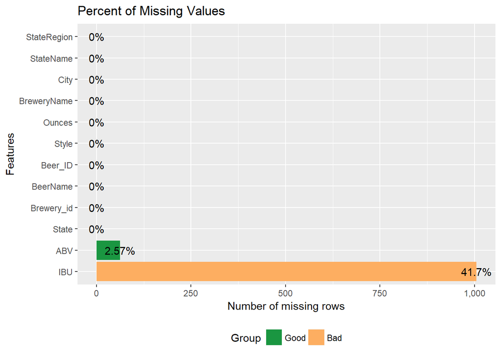

```r
#Graphical representation of missing vaules using 'DataExporer' library
plot_missing(BeersAndBreweries, title = "Percent of Missing Values")
```

```r
#Function to count all NA's in columns
propmiss <- function(dataframe) {
  m <- sapply(dataframe, function(x) {
    data.frame(
      na_count=sum(is.na(x)),
      Obs=length(x),
      perc_missing=sum(is.na(x))/length(x)*100
    )
  })
  d <- data.frame(t(m))
  d <- sapply(d, unlist)
  d <- as.data.frame(d)
  d$variable <- row.names(d)
  row.names(d) <- NULL
  d <- cbind(d[ncol(d)],d[-ncol(d)])
  return(d[order(d$na_count, decreasing=TRUE), ])
}

#show results of NA's counted
BeerColumnInventory_nacount <- propmiss(BeersAndBreweries)
BeerColumnInventory_nacount
```

```
##       variable na_count  Obs perc_missing
## 6          IBU     1005 2410    41.701245
## 5          ABV       62 2410     2.572614
## 1        State        0 2410     0.000000
## 2   Brewery_id        0 2410     0.000000
## 3     BeerName        0 2410     0.000000
## 4      Beer_ID        0 2410     0.000000
## 7        Style        0 2410     0.000000
## 8       Ounces        0 2410     0.000000
## 9  BreweryName        0 2410     0.000000
## 10        City        0 2410     0.000000
## 11   StateName        0 2410     0.000000
## 12 StateRegion        0 2410     0.000000
```

## Visual Display of the Data

To look for trends in the newly described dataset, the team plotted the ABV and IBU against the states to determine which states had the highest median value. *As requested by the client, all of the NA’s have been removed*

- Process of obtating the median values
  - Calculate the median values of ABV & IBU by state
  - Plot the data against states and sort by highest value

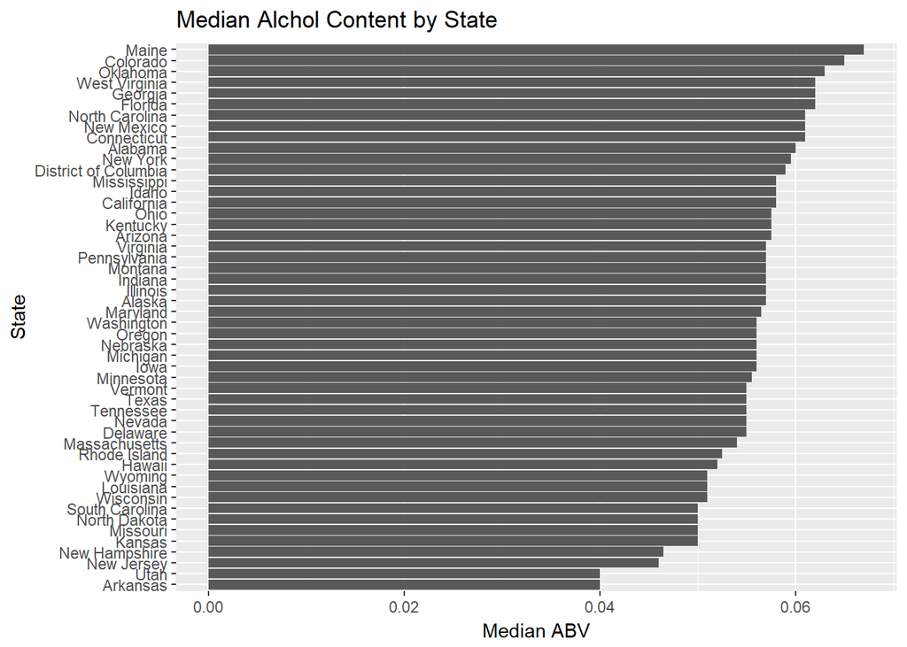

```r
#Make data frame with only State, ABV, IBU
DF_ABV_IBU <- BeersAndBreweries[,c("StateName","ABV","IBU")]

#remove any rows with a NA value using 'complete.cases'
DF_ABV_IBU_noNA <- DF_ABV_IBU[complete.cases(DF_ABV_IBU),]

#Calculate MEDIAN values for ABV&IBU by State
MEDIAN_ABV_IBU_by_State <- aggregate(DF_ABV_IBU_noNA[, 2:3],list(DF_ABV_IBU_noNA$StateName), median)

#Rename column names
colnames(MEDIAN_ABV_IBU_by_State)[colnames(MEDIAN_ABV_IBU_by_State)=='Group.1'] <- 'State'
colnames(MEDIAN_ABV_IBU_by_State)[colnames(MEDIAN_ABV_IBU_by_State)=='ABV'] <- 'Median_ABV'
colnames(MEDIAN_ABV_IBU_by_State)[colnames(MEDIAN_ABV_IBU_by_State)=='IBU'] <- 'Median_IBU'

#plot MEDIAN ABV By State
BarPlot_ABV_byState <- ggplot(data=MEDIAN_ABV_IBU_by_State,
                              aes(x=reorder(State, Median_ABV),
                                  y=Median_ABV)) +
                                  geom_bar(stat="identity")+
                                  coord_flip() +
                                  labs(x="State",
                                       y="Median ABV",
                                       title = "Median Alchol Content by State")
BarPlot_ABV_byState
```

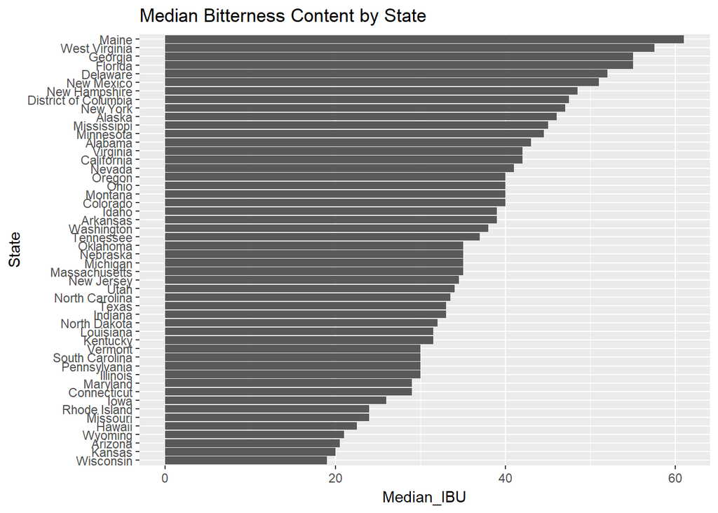

```r
#Plot MEDIAN IBU By State
BarPlot_IBU_byState <- ggplot(data=MEDIAN_ABV_IBU_by_State,
                              aes(x=reorder(State, Median_IBU),
                                  y=Median_IBU)) +
                              geom_bar(stat="identity")+
                              coord_flip()+
                              labs(x="State",
                                   y="Median_IBU",
                                   title = "Median Bitterness Content by State")
BarPlot_IBU_byState
```

## States with highest ABV and IBU

Beer has a few indicators that help us understand a bit more about the beer without having to sample each and every beer for comparison. People naturally have different tastes and preferences for the types of beer they enjoy. Alcohol by Volume (ABV) and International Bittnerness Units (IBU) are some of the most common variables we use to identify the personality of the beer without have to necessarily taste it. A good start is to look at the state that has the highest ABV and IBU respectively. We can deduce the preference of the location based on those factors.

```r
#Find MAX ABV with State
MAX_ABV_byState <- head(BeersAndBreweries[order(BeersAndBreweries$ABV, na.last = TRUE, decreasing=TRUE),c(11,5)],1)
MAX_ABV_byState
```

```
##     StateName   ABV
## 533  Colorado 0.128
```

```r
#Find MAX IBU with State, column has missing values
MAX_IBU_byState <- head(BeersAndBreweries[order(BeersAndBreweries$IBU, na.last = TRUE, decreasing=TRUE),c(11,6)],1)
MAX_IBU_byState
```

```
##      StateName IBU
## 1824    Oregon 138
```

## Summary of ABV

As requested, the client prferred to see summary statistics of the summary variable of ABV.

```r
#Summary Stats of the ABV variable
SUMMARY_ABV <- summary(BeersAndBreweries$ABV)

#Show ABV SUmmary
SUMMARY_ABV
```

```
##    Min. 1st Qu.  Median    Mean 3rd Qu.    Max.    NA's
## 0.00100 0.05000 0.05600 0.05977 0.06700 0.12800      62
```

## Relationship between ABV & IBU

To sum up the request, a scatter plot of the data by region will help the organization determine the relationship between the ABV and IBU. We have color coded the regions as well to help identify the relationship overall as well as by region. It appears that the more ABV we have the more IBU can be expected. We can also deduce a preference by most people to have minimal IBU and ABV.

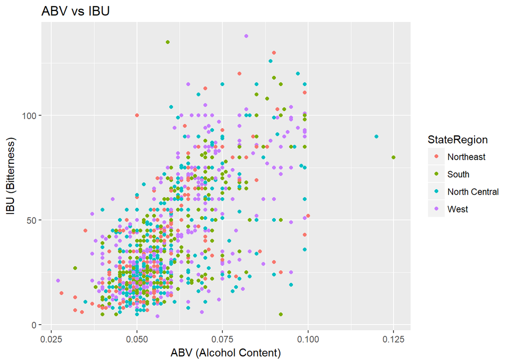

```r
#Merge data with State DB
DF_ABV_IBU_noNA <- merge(DF_ABV_IBU_noNA, StateDB, by="StateName", all = TRUE)

#Remove rows with NA's
DF_ABV_IBU_noNA <- DF_ABV_IBU_noNA[complete.cases(DF_ABV_IBU_noNA),]

#Scatter plot ABV vs IBU and color by StateRegion
ABUvsIBU <- qplot(ABV, IBU,
                  xlab = "ABV (Alcohol Content)",
                  ylab = "IBU (Bitterness)",
                  main= "ABV vs IBU",
                  colour=StateRegion,
                  data=DF_ABV_IBU_noNA)

#Show Scatter Plot
ABUvsIBU
```